# Statistical Inference with GSS Data

## Setup

### Load packages

```r
library(ggplot2)
library(dplyr)
library(statsr)
```

### Load data

```r
load("gss.Rdata")
```

## Part 1: GSS Data

### How Collection Happens and Its Implications for the Scope of Inference

Since 1972, the National Opinion Research Center at the University of Chicago (NORC) has produced the **General Social Survey (GSS)** (initially, surveys were conducted annually; in recent decades, they have been biannual). As a broad survey of U.S. demographics and public opinion, the goal of the GSS is to have “provided politicians, policymakers, and scholars with a clear and unbiased perspective on what Americans think and feel about such issues as national spending priorities, crime and punishment, intergroup relations, and confidence in institutions” (see http://gss.norc.org/).

Each edition of the survey between 1972 and 2004 drew a random **sample** of approximately 1,500 subjects from a target population of non-institutionalized English-speaking persons within the United States 18 years of age or over. Since 2006, Spanish-speaking persons have been added to this sample. In the 2012 edition provided through the Coursera MOOC *Inferential Statistics* from the *Statistic in R* sequence offered by Duke University, for example, the GSS interviewed 1974 people: 1088 women, 886 men; 301 black, 1477 white, and 196 other. These interviews are mostly conducted face-to-face (with a small number computer-assisted or by telephone), and typically take about one and a half hours to complete. And to the extent practicable, the exact wording of questions is retained from year to year to allow for cross-survey comparisons.

The survey’s **study design** is observational rather than experimental: we can’t draw conclusions about the direction of cause-and-effect for any correlations we might discover. But both the large sample size and the survey’s independent random sampling method mean our findings should be generalizable to the broader target population and should allow for making solid inferential claims about the center and spread of this data.

Nevertheless, the choice to sample from only “non-institutionalized” adults means the data will likely underrepresent those types of people who are demographically *overrepresented* in the population of institutionalized U.S. adults — not a minor consideration for a survey that attempts to cover such matters as the social attitudes toward race, income inequality, access to healthcare, and the role of government: questions such as those that we’ll address below.

## Part 2: Research Questions

Though the GSS ranges across a wide swatch of items of potential interest in 21st-century American culture and social life, for this project I’ll be looking at a small subset of questions concerning **attitudes toward government intervention**: in matters of income inequality (`HELPPOOR`), healthcare (`HELPSICK`), the historical impact of race (`HELPBLK`), and in general (`HELPNOT`).

Asking subjects to place themselves on a scale of 1 to 5, the survey asks:

- VAR: `HELPPOOR` – Some people think that the government in Washington should do everything possible to improve the standard of living of all poor Americans; they are at Point 1 on this card. Other people think it is not the government’s responsibility, and that each person should take care of himself; they are at Point 5 on this card.
- VAR: `HELPSICK` – In general, some people think that it is the responsibility of the government in Washington to see to it that people have help in paying for doctors and hospital bills. Others think that these matters are not the responsibility of the federal government and that people should take care of these things themselves.
- VAR: `HELPBLK` – Some people think that (Blacks/Negroes/African-Americans) have been discriminated against for so long that the government has a special obligation to help improve their living standards. Others believe that the government should not be giving special treatment to (Blacks/Negroes/African-Americans).
- VAR: `HELPNOT` – Some people think that the government in Washington is trying to do too many things that should be left to individuals and private businesses. Others disagree and think that the government should do even more to solve our country’s problems. Still others have opinions somewhere in between.

In what follows below, I’d like to explore the answers to these questions and how those answers have shifted – whether in tandem, or in different directions – in the surveys done between 2008 and 2012, covering a period of American history that brought attitudes toward these subjects into sharp focus: the election to the presidency of Barack Obama, the U.S.’s first black president; the passage of the Affordable Care Act under his administration, a controversial attempt at providing something like guaranteed healthcare coverage; the limited-government backlash movement known as the “Tea Party” that brought a wave of members into Congress in 2010 dedicated to the ideal of a sharply limited; and Obama’s re-election in 2012, a result that set the stage for a swing of the pendulum in the next cycle of U.S. politics that brought about the very different politics represented by Donald Trump.

Specifically, I’d like to ask the following:

1. In 2012, how supportive/resistant were Americans to the idea that **race continues to matter** in U.S. life and **requires active measures** on the part of the federal government to address its persistent impact?
2. How did the level of support/resistance change between the years of Obama’s election in 2008 and re-election in 2012, and **was that change significant**?

The answers to these questions should go some way toward helping us understand the grounds upon which U.S. racial politics have stood in the period since.

## Part 3: Exploratory data analysis

We’ll start by taking an overview of how attitudes about the role of government in addressing racial inequality changed, or didn’t, between 2008 and 2012.

LONG NOTE (FAIR WARNING: IF YOU DON’T CARE, SKIP!): In the version of the GSS dataset provided as part of the *Inferential Statistics* MOOC, `helpblk` and other variables have been **“cleaned”** to eliminate non-answers. Unfortunately, what this means in practice is that the range of responses for these questions has been transformed from a 5-level integer Likkert scale to a factored variable with just three levels – in the case of `helpblk`, to just `Govt Help Blks`, `Agree With Both`, and `No Special Treatment`. In the original data, these were points 1, 3, and 5 on the scale, respectively, and responses along the 2 and 4 points of the scale have simply been eliminated in the cleaned version – treated as non-responses.

This isn’t ideal from the perspective of giving us the whole picture. But since I plan to concentrate on those shifts at the end of the spectrum – “Govt Help Blks” and “No Special Treatment” – it will still work for our purposes (the counts for those responses are unchanged between the raw and cleaned versions of the dataset).

Nevertheless, I’d first like to at least get a count of the total respondents to this question along the five-point scale. So I’m going to go back to the original dataset available directly from the GSS to get the total number of respondents to this question from 2008 and 2012, which will then be available to use in the proportion calculations derived from the cleaned dataset.

```r
# WARNING: The following code uses what turns out to be a very large dataset from the GSS:
# 62,466 rows over 5,897 variables, and using 399.7 MB of memory if downloaded.

# So, rather than ask you to run this here and bring your computer to a grinding halt,
# I'll show you the steps I took -- which you could replicate on your own -- but comment them out
# and then just show the results and store them as variables for use in the rest of this analysis.

# To read in the data from the SPSS-ready format in which NORC provides the GSS data (inclusive through 2016),
# I'm following the guidelines of a tutorial by Douglas M. Wiig on his R Statistics and Programming blog at:
# https://dmwiig.net/2014/08/03/r-tutorial-using-r-to-work-with-datasets-from-the-norc-general-social-science-survey/

# First, we load in two libraries ("foreign" is native to R; you would need to install "Hmisc")

# library(foreign)
# library(Hmisc)

# Then read in the data from the SPSS (".sav") format in which NORC provides it.
# I downloaded this as .zip file "GSS7216_R3" to the folder in which my R project resides, from
# http://gss.norc.org/documents/spss/GSS_spss.zip

# gssFull <- spss.get("GSS7216_R3.sav", use.value.labels = TRUE)

# Now, we look at the distribution of the HELPBLK variable for 2008 and 2012. First, 2008:

# gssFull %>% filter(YEAR == 2008, !is.na(HELPBLK)) %>% group_by(HELPBLK) %>% summarise(count = n())

#  HELPBLK              count
#  <fct>                <int>
# 1 GOVT HELP BLKS         125
# 2 2                      107
# 3 AGREE WITH BOTH        440
# 4 4                      253
# 5 NO SPECIAL TREATMENT   383

# With:
# TOTAL                   1308

nHelpblk08 = 1308

# And for 2012:

# gssFull %>% filter(YEAR == 2012, !is.na(HELPBLK)) %>% group_by(HELPBLK) %>% summarise(count = n())

#  HELPBLK              count
#  <fct>                <int>
# 1 GOVT HELP BLKS          93
# 2 2                      117
# 3 AGREE WITH BOTH        394
# 4 4                      231
# 5 NO SPECIAL TREATMENT   447

# With:
# TOTAL                   1282

nHelpblk12 = 1282

# Now we have total non-NA responses for this question for both years, against which we can gauge the
# proportion of particular answers.

# And, just for historical interest (and because it actually complicates the point I'm trying to make!),
# here's 2016 -- the year of Donald J. Trump's election to the U.S. presidency:

# gssFull %>% filter(YEAR == 2016, !is.na(HELPBLK)) %>% group_by(HELPBLK) %>% summarise(count = n())

#  HELPBLK              count
#  <fct>                <int>
# 1 GOVT HELP BLKS         246
# 2 2                      220
# 3 AGREE WITH BOTH        608
# 4 4                      371
# 5 NO SPECIAL TREATMENT   430

# With:
# TOTAL                   1875

nHelpblk16 = 1875
pGovt16 = 246/1875
pNoSpec16 = 430/1875
```

Which is to say: for the question on the obligation of the U.S. government to “help blacks” vs. provide “no special treatment,” we have 1308 total responses for 2008, and 1282 responses in 2012.

SHORT NOTE WITHIN A LONG NOTE: Though it was good R practice to go through the original raw dataset, there is a an easier “cheater’s” way – i.e., the sane person’s way – to get the same basic numbers. Namely, these are included as part of the published GSS’s codebook for this data at http://gss.norc.org/get-documentation. (See pages 576 through 579 of the PDF)

We’ll use these total reponse numbers for 2008 and 2012 as the basis for understanding the proportions of responses at either end of the spectrum – “Govt Help Blks” and “No Special Treatment” – for this question.

Let’s see what those **proportions** were.

```r
yesHelpblk08 <- gss %>%
  filter(year == '2008' & !is.na(helpblk)) %>%
  group_by(helpblk) %>%
  summarise(count08 = n(), proportions08 = n()/nHelpblk08)

yesHelpblk08
```

```
## # A tibble: 3 x 3
##   helpblk              count08 proportions08
##   <fct>                  <int>         <dbl>
## 1 Govt Help Blks           125        0.0956
## 2 Agree With Both          440        0.336
## 3 No Special Treatment     383        0.293
```

```r
yesHelpblk12 <- gss %>%
  filter(year == '2012' & !is.na(helpblk)) %>%
  group_by(helpblk) %>%
  summarise(count12 = n(), proportions12 = n()/nHelpblk12)

yesHelpblk12
```

```
## # A tibble: 3 x 3
##   helpblk              count12 proportions12
##   <fct>                  <int>         <dbl>
## 1 Govt Help Blks            93        0.0725
## 2 Agree With Both          394        0.307
## 3 No Special Treatment     447        0.349
```

And let’s also see **what that looks like** across these two editions of the survey:

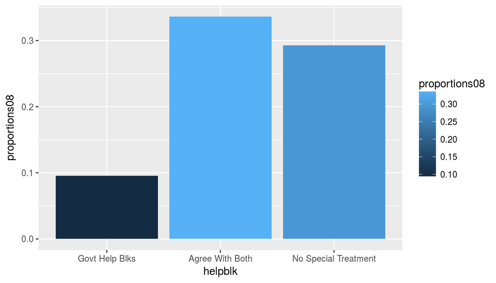

```r
ggplot(yesHelpblk08,
       aes(x = helpblk, y = proportions08, fill = proportions08)) + geom_col()
```

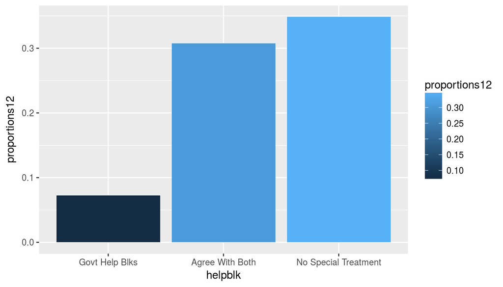

```r
ggplot(yesHelpblk12,
       aes(x = helpblk, y = proportions12, fill = proportions12)) + geom_col()
```

So… there *does* seem to have been a shift to the right on this question between 2008 and 2012 – all puns intended – with fewer respondents agreeing with the statement “that (Blacks/Negroes/African-Americans) have been discriminated against for so long that the government has a special obligation to help improve their living standards” (a 2.3% drop between the two surveys), and more respondents agreeing with the statement “that the government should not be giving special treatment to (Blacks/Negroes/African-Americans)” (a 5.6% increase). (The 2.9% drop in the “Agree With Both” proportion might also point to more polarized attitude on this question.)

**But are these changes significant?**

In the following section, we’ll ask whether the tools of **statistical inference** can tell us, with confidence, whether these changes – visually striking on their face – are signficant or whether, on the other hand, they are simply differences we could expect within the normal range of sampling variation.

## Part 4: Inference

Our basic question about the shift in attitudes between 2008 and 2012 on the role government intervention in addressing race-based inequality is really two questions: 1) what do our sample proportions tell us about those attitudes in the target population in 2008 and 2012? and 2) Do the differences in the sample proportions between those survey years suggest a significant difference across that period for our target population of U.S. (non-institutionalized) adults?

### Question 1 - Sample Proportions

*Q: In 2012, how supportive/resistant were Americans to the idea that **race continues to matter** in U.S. life and **requires active measures** on the part of the federal government to address its persistent impact?*

To answer this question, we’ll determine the sample proportions for the responses at the two far ends of the five-point spectrum on the GSS `helpblk` survey question for 2012, and construct **confidence intervals** around those proportions that allow us to state, with a 95% **confidence level**, that the true population parameter – the proportion of the full population of non-institutionalized U.S. adults who we would expect answer in the same way – would fall within the margin of error established by these intervals.

Our calculations depend on the premise of the **Central Limit Theorem**: that, given what we know about the shape and spread of responses within our sample, we can assume that with enough samples we would see a distribution of the sample statistic (in this case, the proportion of our sample answering a question a particular way) that would be centered on the true **population parameter**, with a **margin of error** determined by our desired level of confidence and inversely related to our sample size.

Certain **conditions** about our sample would need to be met for this to be the case:

- **Independence of observations** – Since the survey design tells us the respondents are randomly chosen, and since their number ($\approx$ 1,500) is well under 10% of the total target U.S. population, this condition is met.
- **Sample size and skew** – for 2012, both the number of successes and failures for each response (those giving a particular answer vs. those not) are well above the 10 used as the general cutoff for determining whether a sample meets CLT conditions.

With our conditions met, we can calculate the confidence interval as:

$$CI = \hat{p} \pm Z^\star*SE$$

Where $\hat{p}$ is our sample success proportion, ${Z}^\star$is the critical value (cutoff for significance) for a Z-score distribution at our desired level of confidence (for a 95% confidence level, ${Z}^\star$is approx. 1.96), and $SE$ is the standard error assumed for sampling distributions at our proportion of sample successes and sample size.

$SE$ is calculated as:

$$SE = \sqrt{\frac{\hat{p}(1-\hat{p})}{n}}$$

So let’s construct a confidence interval for the population proportion of respondents who we would expect to answer that the government should be expected to play a role in addressing racial inequality in 2012.

```r
# Determine our desired confidence level at 95% and assign the Z* level associated with it.

zStar95 <- qnorm(0.975)    # using statsr function to get Z score for two-tailed sig. of 5%/2

# Then, for 2012, find the proportion who provided "Govt Help Blks" response

nHelpblk12 <- nHelpblk12     # from above

proportion_helpblk2012 <- gss %>%
  filter(year == '2012' & !is.na(helpblk) & helpblk == 'Govt Help Blks') %>%
  summarise(n()/nHelpblk12)
pGovt12 <- as.numeric(proportion_helpblk2012)

# Based on success proportion and sample size, calculate Standard Error, and from it the Margin of Error

seGovt12 <- sqrt((pGovt12 * (1 - pGovt12))/nHelpblk12)
meGovt12 <- zStar95 * seGovt12
lowGovt12 <- pGovt12 - meGovt12   # low end of confidence interval
highGovt12 <- pGovt12 + meGovt12  # high end of confidence interval
```

THE RESULTS: In terms of 2012 respondents to the `helpblk` question, 0.073 of the 1282 who answered on the five-point scale put their response at 1 (‘Govt Help Blks’). This means that our standard error $SE$ will be the square root of 0.073 $*$ (1 - 0.073) divided by 1282 = 0.007, and our margin of error $ME$ will be our ${Z}^\star$ value 1.96 $*$ our $SE$ value 0.007 $=$ 0.014.

Our confidence interval $CI$ for this 2012 `Govt Help Blks` proportion will, therefore, be 0.073 $\pm$ 0.014. This means we can say with 95% confidence that the true proportion of our 2012 target population who would say that the government should do more to help its African American citizens would fall between 0.058 and 0.087.

We can carry out this same process for the other three of the four data points in which we’re for this research question, which is to say, the proportion answering `helpblk` on either end of the 1 to 5 scale (‘Govt Help Blks’ and ‘No Special Treatment’) for 2012 vs. 2008.

```r
# 2012, "No Special Treatment"

proportion_no_helpblk2012 <- gss %>%
  filter(year == '2012' & !is.na(helpblk) & helpblk == 'No Special Treatment') %>%
  summarise(n()/nHelpblk12)
pNoSpec12 <- as.numeric(proportion_no_helpblk2012)
meNoSpec12 <- zStar95 * sqrt((pNoSpec12 * (1 - pNoSpec12))/nHelpblk12)

# 2008, "Govt Help Blks"

proportion_helpblk2008 <- gss %>%
  filter(year == '2008' & !is.na(helpblk) & helpblk == 'Govt Help Blks') %>%
  summarise(n()/nHelpblk08)
pGovt08 <- as.numeric(proportion_helpblk2008)
meGovt08 <- zStar95 * sqrt((pGovt08 * (1 - pGovt08))/nHelpblk08)

# 2008, "No Special Treatment"

proportion_no_helpblk2008 <- gss %>%
  filter(year == '2008' & !is.na(helpblk) & helpblk == 'No Special Treatment') %>%
  summarise(n()/nHelpblk08)
pNoSpec08 <- as.numeric(proportion_no_helpblk2008)
meNoSpec08 <- zStar95 * sqrt((pNoSpec08 * (1 - pNoSpec08))/nHelpblk08)
```

The confidence intervals for these four proportions, then, are:

**Proportion and CI for “Govt Help Blks”**

CI for 2012: 0.073 $\pm$ 0.014, or (0.058, 0.087)

CI for 2008: 0.096 $\pm$ 0.016, or (0.08, 0.111) –>

**Proportion and CI for “No Special Treatment”**

CI for 2012: 0.349 $\pm$ 0.026, or (0.323, 0.375)

CI for 2008: 0.293 $\pm$ 0.025, or (0.268, 0.317)

Now that we understand what we can infer about target population attitudes on this question in these two years of the GSS survey, we can address whether the changes we’re seeing in the sample proportions between 2008 and 2012 – a drop in the proportion responding that government should help African Americans, a rise in the proportion responding that African Americans should receive no special treatment from the government – are significant.

We do this now in answer to the following question.

### Question 2 - Differences Between Two Proportions

*Q: How did the level of support/resistance change between the years of Obama’s election and re-election, and is this change significant?*

We know that the `helpblk` proportions for the `Govt Help Blks` and `No Special Treatment` responses are not the same in 2012 as they were in 2008. But **are the differences in those proportions statistically significant?**

To find out, we’ll set up a **hypothesis test**, starting with the `Govt Help Blks` response affirming the belief that the government has a role to play in addressing and ameliorating the present-day effects of the history of race relations in the U.S.

Our **null hypothesis** will be that there is no significant difference between the proportion of the target population who would provide this response in 2008 and in 2012, and that the difference we’re seeing in our survey numbers simply falls within the expected “noise” level of the process of sampling. Our **alternative hypothesis** will be that the difference we’re seeing in our samples is significant beyond this expected noise level.

$$H_0: p_{2012} - p_{2008} = 0$$
$$H_A: p_{2012} - p_{2012} \neq 0$$
Our conditions for conducting this test in relation to the Central Limit Theoresm remain as before: the samples are independent and the size/skew of our sample raises no red flags.

The **Z score** from which we’ll derive our **p-value** – essentially, the probability that our sample could deliver results as extreme or greater than what we’ve observed even if the null hypothesis is true – is based on the change we observe in our two sample proportions and the difference between this change and the change we would expect from our null hypothesis (no change!), normalized through factoring this difference by our standard error for our samples.

$$Z_{diff} = \frac{Observed_{diff} - Expected_{diff}}{SE_{diff}}$$

The standard error in the case of the difference between two proportions relies on a **pooled proportion** to estimate a weighted average proportion from potentially differently sized samples, summing the the total numbers of “successes” for the response in each sample (i.e., respondents answering “Govt Help Blks”) divided by the sum of both total sample sizes…

$$\hat{p}_{pooled} = \frac{Successes_{sample1}+Successes_{sample2}}{n_{sample1}+n_{sample2}}$$
…with the Standard Error then caluculated as:

$$SE = \sqrt{\frac{\hat{p}_{pooled}*(1-\hat{p}_{pooled})}{n_{sample1}}+\frac{\hat{p}_{pooled}*(1-\hat{p}_{pooled})}{n_{sample2}}}$$

Since we are testing our hypotheses at the 95% confidence level, we will be able to reject the null hypothesis only if the p-value associated with our Z score is less than 0.05.

```r
# Calculate Z score: observed difference is the proportion answering "Govt Help Blacks" in 2012 vs. in 2008,
# and expected difference is our null hypothesis expectation of no change.

pDiffGovt = pGovt12 - pGovt08
pNullGovt = 0

# Standard error for the difference between two proportions uses pooled proportion of successes.

sucGovt08 <- gss %>% filter(year == '2008' & !is.na(helpblk) & helpblk == 'Govt Help Blks') %>%
  summarise(countGov08 = n())
sucGovt08 <- as.numeric(sucGovt08)

sucGovt12 <- gss %>% filter(year == '2012' & !is.na(helpblk) & helpblk == 'Govt Help Blks') %>%
  summarise(countGov12 = n())
sucGovt12 <- as.numeric(sucGovt12)

pPooledGovt = (sucGovt12 + sucGovt08) / (nHelpblk12 + nHelpblk08)
seDiffGovt = sqrt(((pPooledGovt * (1-pPooledGovt)) / nHelpblk12) +
                    ((pPooledGovt * (1-pPooledGovt)) / nHelpblk08))

# Then Z score is (observed - expected) divided by the standard error.

zDiffGovt = (pDiffGovt - pNullGovt) / seDiffGovt

# And the p-value is the one associated with this Z-score.

pvalDiffGovt <- pnorm(zDiffGovt)

meDiffGovt <- zStar95 * sqrt((pGovt08 * (1 - pGovt08))/nHelpblk08 + (pGovt12 * (1 - pGovt12))/nHelpblk12)
ciLowerDiffGovt <- pDiffGovt - meDiffGovt
ciUpperDiffGovt <- pDiffGovt + meDiffGovt
```

The proportion of GSS respondents answering “Govt Help Blks” dropped from 0.096 in 2008 to 0.073 in 2012: a difference of -0.023. With a pooled proportion of 0.084 and a consequent Standard Error of 0.011, our Z score for this change works out to -0.023 / 0.011 $=$ -2.11.

The probability that we would see a difference this extreme or more is expressed in the p-value associated with this Z score: 0.034 (doubling the value 0.017 to account for both tails of the distribution). This value falls below the 0.05 threshold of signficance at the 95% confidence level we are using, so we can safely reject the null hypothesis. (This is confirmed by the confidence interval for this difference of (-0.044, -0.002), an interval that excludes the value 0 and thus tells us with 95% confidence that “no change” is not the true population parameter for the difference in proportions.)

It appears that a significantly lower proportion of people in 2012 relative to 2008 were willing to say that the government should play an active role in addressing the inequalities resulting from the history of race in the U.S.

Is this also the case on the other end of the scale, for the response that African American citizens should receive “No Special Treatment” from the government?

```r
# Calculate successes, pooled proportion, standard error, Z score, p-value, and confidence interval:

sucNoSpec08 <- gss %>% filter(year == '2008' & !is.na(helpblk) & helpblk == 'No Special Treatment') %>%
  summarise(countNoSpec08 = n())
sucNoSpec08 <- as.numeric(sucNoSpec08)

sucNoSpec12 <- gss %>% filter(year == '2012' & !is.na(helpblk) & helpblk == 'No Special Treatment') %>%
  summarise(countNoSpec12 = n())
sucNoSpec12 <- as.numeric(sucNoSpec12)

pPooledNoSpec = (sucNoSpec12 + sucNoSpec08) / (nHelpblk12 + nHelpblk08)
seDiffNoSpec = sqrt(((pPooledNoSpec * (1-pPooledNoSpec)) / nHelpblk12) +
                    ((pPooledNoSpec * (1-pPooledNoSpec)) / nHelpblk08))

zDiffNoSpec = ((pNoSpec12 - pNoSpec08) - 0) / seDiffNoSpec

pvalDiffNoSpec <- pnorm(zDiffNoSpec)

meDiffNoSpec <- zStar95 * sqrt((pNoSpec08 * (1 - pNoSpec08))/nHelpblk08 + (pNoSpec12 * (1 - pNoSpec12))/nHelpblk12)
ciLowerDiffNoSpec <- (pNoSpec12 - pNoSpec08) - meDiffNoSpec
ciUpperDiffNoSpec <- (pNoSpec12 - pNoSpec08) + meDiffNoSpec
```

The proportion of GSS respondents answering “No Special Treatment” rose from 0.293 in 2008 to 0.349 in 2012: a difference of 0.056. With a pooled proportion of 0.32 and a consequent Standard Error of 0.018, our Z score for this change works out to 0.056 / 0.018 $=$ 3.046.

The probability that we would see a difference this extreme or more is expressed in the p-value associated with this Z score: 0.002 (doubling the value 0.001 to account for both tails of the distribution). This value falls below the 0.05 threshold of signficance at the 95% confidence level we are using (indeed, it would fall below a 99% confidence level threshold), so we can safely reject the null hypothesis. (The confidence interval for this difference of (0.02, 0.092) confirms that the “no change” value of 0 is excluded at a 95% confidence level.)

So, as with the drop in the proportion of “Govt Help Blks” responses, a significantly higher proportion of people in 2012 relative to 2008 were willing to say African Americans should receive no special treatment from the government in the service of addressing racial inequalities.

## Limitations and Future Directions

One implication of these findings is that, between 2008 and 2012, attitudes among the general adult, non-institutionalized U.S. population hardened against the idea that the government had a role in addressing the historical and structural inequalities faced by African American citizens. And, one could speculate, this shift was part of a backlash against the 2008 election of the U.S.’s first black president and a hint at the swing to the right that anticipated the 2016 election of Donald J. Trump.

But there are two significant questions we might ask that would complicate this narrative.

1. First, we might want to ask if this shift between 2008 and 2012 was part of a longer historical trend or a blip in the larger narrative? In this sense, the answer to the GSS `helpblk` question in 2016 – the year of Trump’s electoral victory – is interesting and instructive, as we’ll see below.
2. And, second, we could explore whether this shift represented a particular rethinking of race, or whether it just was part of a more general trend of anti-Big Government thinking of the sort that brought about the “Tea Party” wave of limited government conservatives that were elected to Congress in the 2010 midterms. Were changes in attitude with respect to federal intervention in race matter sharper than that broader shift against the idea of government intervention in general? In particular, were the changes more significant than those in areas coded as non-racial, such as the GSS questions about the government’s role in providing access to healthcare or addressing income inequality?

On the second question, I’ll have little to say here – that will have to be a question for another day – other than the fact that these results would be a good candidate for a chi-square independence test analysis.

But on the first, it turns out that there’s a surprise twist. In 2016, the proportion answering “Govt Help Blks” reversed course, rising to 0.131 from the 0.073 we saw in 2012. Likewise, the proportion answering “No Special Treatment” *dropped* sharply, from 0.349 in 2012 to 0.229 in the 2016 survey. For both of these results, the p-value is < 0.0001, suggesting a very significant reversal of the shift we saw between 2008 and 2012, and totally ruining the story I thought I was telling!

NOTE: You may have noticed that so far I’ve run my inference tests the old-fashioned way, and haven’t taken advantage of the nifty `inference()` function provided as part of the `statsr` package developed by the Duke team for this Coursera MOOC. I made this choice due to the missing values in the cleaned data set, but I will show the work below using this function on the full GSS dataset referred to at the beginning of this project for the four hypothesis tests I’ve conducted on year-to-year differences in proportions.

```r
# Here are the hypothesis tests run using the statsr packages inference() function,
# run on two-year comparison subsets drawn from the unexpurgated GSS dataset at
# http://gss.norc.org/documents/spss/GSS_spss.zip

# Create subset for 2008 to 2012 comparisons
# gss0812 <- gssFull %>% filter(!is.na(HELPBLK), YEAR == "2008" | YEAR == "2012")

# Run hypothesis test for the difference in the proportion answering "Govt Help Blks"

# inference(data = gss0812, y = HELPBLK, success = "GOVT HELP BLKS", x = as.factor(YEAR),
#           type = "ht", method = "theoretical", null = 0, alternative = "twosided",
#           conf_level = 0.95, sig_level = 0.5, statistic = "proportion")

# RESULTS
# n_2008 = 1308, p_hat_2008 = 0.0956
# n_2012 = 1282, p_hat_2012 = 0.0725
# H0: p_2008 =  p_2012
# HA: p_2008 != p_2012
# z = 2.1099
# p_value = 0.0349

# Run hypothesis test for the difference in the proportion answering "No Special Treatment"

# inference(data = gss0812, y = HELPBLK, success = "NO SPECIAL TREATMENT", x = as.factor(YEAR),
#           type = "ht", method = "theoretical", null = 0, alternative = "twosided",
#           conf_level = 0.95, sig_level = 0.5, statistic = "proportion")

# RESULTS
# n_2008 = 1308, p_hat_2008 = 0.2928
# n_2012 = 1282, p_hat_2012 = 0.3487
# H0: p_2008 =  p_2012
# HA: p_2008 != p_2012
# z = -3.0458
# p_value = 0.0023

# Create subset for 2012 to 2016 comparisons
# gss0812 <- gssFull %>% filter(!is.na(HELPBLK), YEAR == "2016" | YEAR == "2012")

# Run hypothesis test for the difference in the proportion answering "Govt Help Blks"

# inference(data = gss1216, y = HELPBLK, success = "GOVT HELP BLKS", x = as.factor(YEAR),
#           type = "ht", method = "theoretical", null = 0, alternative = "twosided",
#           conf_level = 0.95, sig_level = 0.5, statistic = "proportion")

# RESULTS
# n_2012 = 1282, p_hat_2012 = 0.0725
# n_2016 = 1875, p_hat_2016 = 0.1312
# H0: p_2012 =  p_2016
# HA: p_2012 != p_2016
# z = -5.228
# p_value = < 0.0001

# Run hypothesis test for the difference in the proportion answering "No Special Treatment"

# inference(data = gss1216, y = HELPBLK, success = "NO SPECIAL TREATMENT", x = as.factor(YEAR),
#           type = "ht", method = "theoretical", null = 0, alternative = "twosided",
#           conf_level = 0.95, sig_level = 0.5, statistic = "proportion")

# RESULTS
# n_2012 = 1282, p_hat_2012 = 0.3487
# n_2016 = 1875, p_hat_2016 = 0.2293
# H0: p_2012 =  p_2016
# HA: p_2012 != p_2016
# z = 7.352
# p_value = < 0.0001
```